# Using Twitter’s algorithms to detect outliers and change points in time series data

March 10, 2016

## Introduction

- Background
- PhD in Bioinformatics, MS Biostatistics (U of M)
- Data Scientist at Trinity Health (1.5 years)
- Two boys (2.5 and 0.25 years)
- Closet metalhead

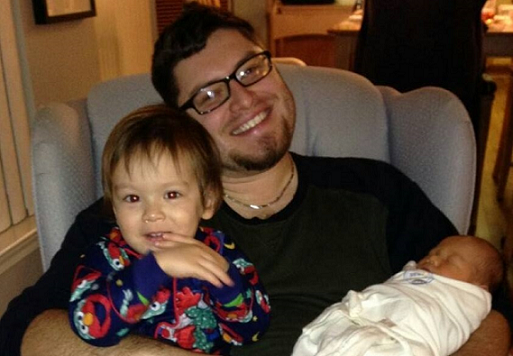

## Motivation

- Medical billing codes assigned to encounter
- Aggregate code usage (monthly)
- "Did we observe more live births at SJMHS than usual in November?"

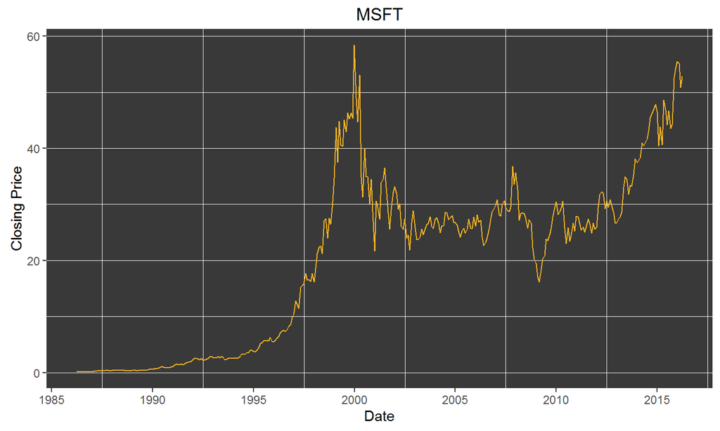

## Decomposition of time series

**STL: a seasonal-trend decomposition procedure based on LOESS**  
*Robert B. Cleveland, William S. Cleveland, Jean E. McRae, and Irma Terpenning*  
Journal of Official Statistics (1990)

- Trend component: low-frequency variation and long-term changes in data
- Seasonal component: seasonal variation in data
- Remainder component: variation in data without trend and seasonal components

For \(\nu\) in \(1\dots N\),

\[Y_\nu = T_\nu + S_\nu + R_\nu\]

## LOESS fit poorly approximates underlying trend

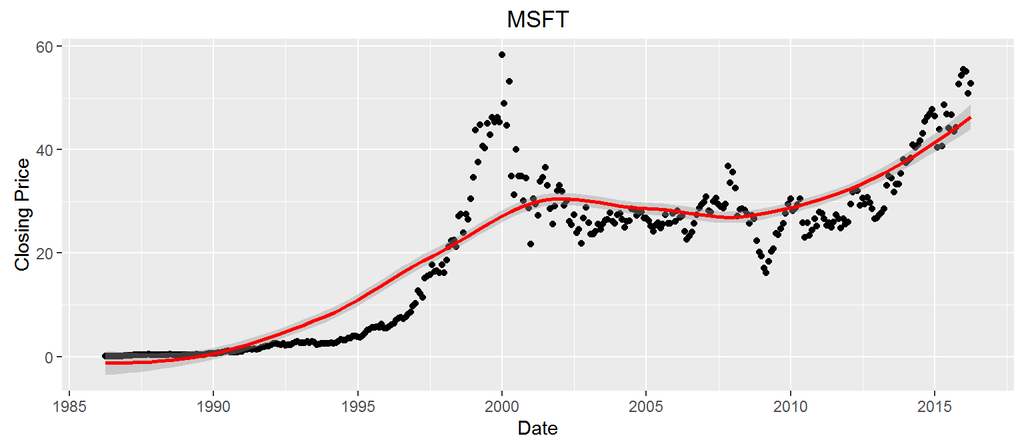

```r
msft_data %>%
  ggplot(aes(x = timestamp, y = count)) +
  geom_point() +
  geom_smooth(method = "loess", color = "red") +
  xlab("Date") +
  ylab("Closing Price") +
  ggtitle("MSFT")
```

## STL to separate time series components

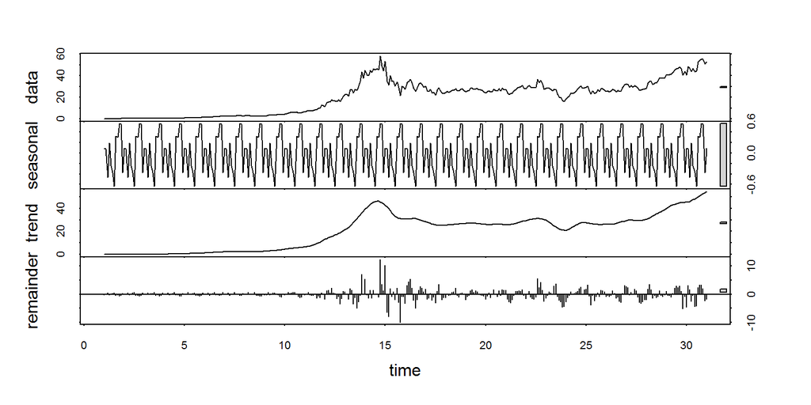

```r
msft_zoo <- zoo::zoo(msft_data$count, order.by = msft_data$timestamp) # i like zoo, so sue me
msft_ts <- stats::ts(msft_zoo, frequency = 12)                        # monthly data, so 12 obs./period
msft_stl <- stats::stl(msft_ts, s.window = "periodic")                # seasonal decomposition by loess
plot(msft_stl)
```

## Increased robustness if outliers are expected

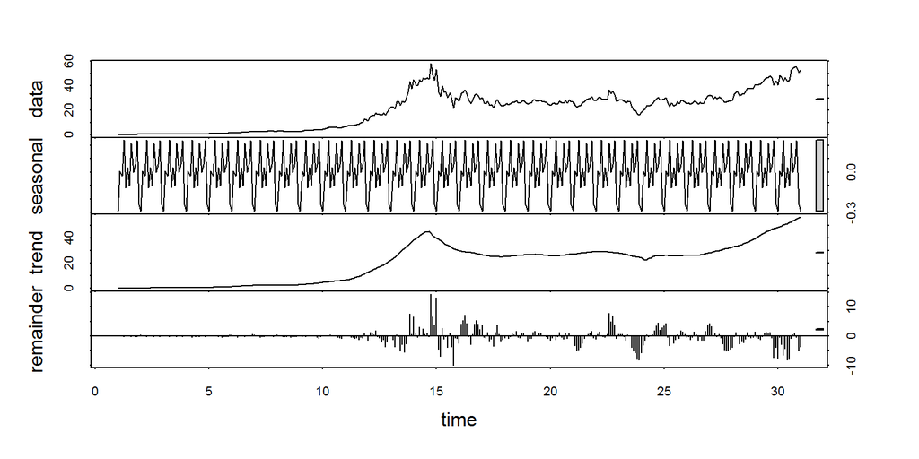

```r
msft_stl <- stats::stl(msft_ts, s.window = "periodic",
                       s.degree = 1,                 # seasonal polynomial fit degree, {0, 1}
                       robust = T)                   # robust fitting
#                      inner = if(robust)  1 else 2, # backfitting iterations
#                      outer = if(robust) 15 else 0  # robustness iterations
plot(msft_stl)
```

## Outlier detection from univariate time series

\[G = \frac{\max\limits_{\nu}\left|R_\nu-\bar{R}\right|}{s}\]

\(H_0\): no outliers

\(H_a\): at least one outlier

For two-sided test, the null hypothesis is rejected if

\[G \gt \frac{N-1}{\sqrt{N}} \sqrt{\frac {t^2_{\alpha/(2N),N-2}} {N-2+t^2_{\alpha/(2N),N-2}} } \]

## Extracting the residual component from STL

```r
names(msft_stl)
```

```
## [1] "time.series" "weights"     "call"        "win"         "deg"
## [6] "jump"        "inner"       "outer"
```

```r
head(msft_stl$time.series)
```

```
##          seasonal     trend    remainder
## [1,] -0.292745057 0.1035591  0.289185945
## [2,]  0.006206882 0.1111303 -0.007337161
## [3,] -0.027554415 0.1187014  0.028852968
## [4,]  0.238298734 0.1291275 -0.257426188
## [5,] -0.117503871 0.1395535  0.077950408
## [6,]  0.032527383 0.1519589 -0.084486241
```

## Approximate normality of residual component

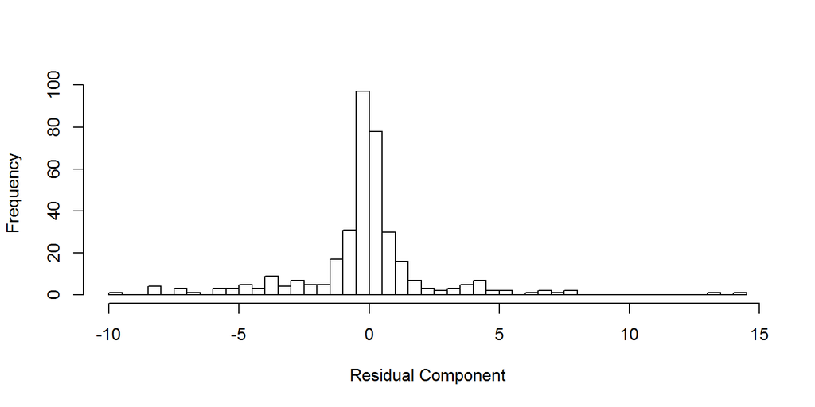

```r
residComp <- msft_stl$time.series[,3]
hist(residComp, breaks = 50, main = "", xlab = "Residual Component")
```

## AnomalyDetection from Twitter

- Designed to detect outliers in time series data
- Seasonal hybrid ESD (S-H-ESD)
- Uses piecewise median instead of STL trend
- More robust to extreme outliers
- \(Y_\nu\) is split into non-overlapping windows

Residual component is calculated as:

\[R_\nu = Y_\nu - S_\nu - \tilde{Y_\nu}\]

Then ESD is calculated using this residual and median absolute deviation (MAD)

\[G = \frac {\max\limits_{\nu} \left| R_\nu-\tilde{R} \right| } {median \left| R_\nu - \tilde{R} \right| } \]

## AnomalyDetection syntax and results

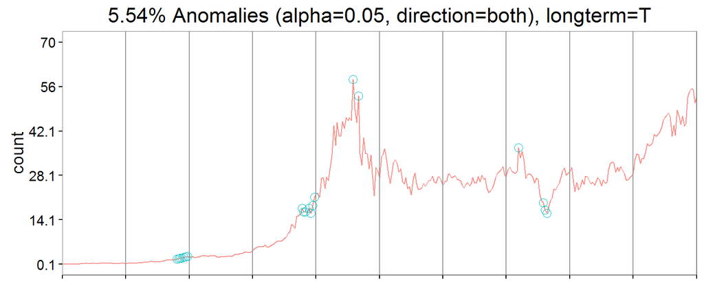

```r
msft_vec <- msft_data$count[order(msft_data$timestamp)]
outliers <- AnomalyDetectionVec(msft_vec, plot = T,
                                direction = 'both',   # detect positive and negative spikes
                                period = 12,          # number obs. in single period
                                longterm_period = 72) # number obs. for which trend is "flat"
outliers$plot
```

## BreakoutDetection from Twitter

- Designed to detect mean shifts in time series data
- E-Divisive with Medians (EDM)
- Robust to extreme outliers
- Non-parametric

For \(Y_1,\,Y_2,\,\dots,\,Y_N\), let there be a point \(\tau\) where

\[Y_1,\,Y_2,\,\dots,\,Y_\tau \thicksim F\]

\[Y_{\tau+1},\,Y_{\tau+2},\,\dots,\,Y_N \thicksim G\]

Kolmogorov-Smirnov test to compare distributions

\(H_0 \colon F = G\)

\(H_a \colon F \neq G\)

But we don't know the location and number of \(\tau\)…

## E-Divisive (with medians)

- algorithms to narrow search space
- Twitter's modification uses medians to estimate the energy distance between two distributions
- Energy distance combines within and between levels of variation
- Tree searching (bisection) limits the space in which this must be calculated

## BreakoutDetection syntax and results

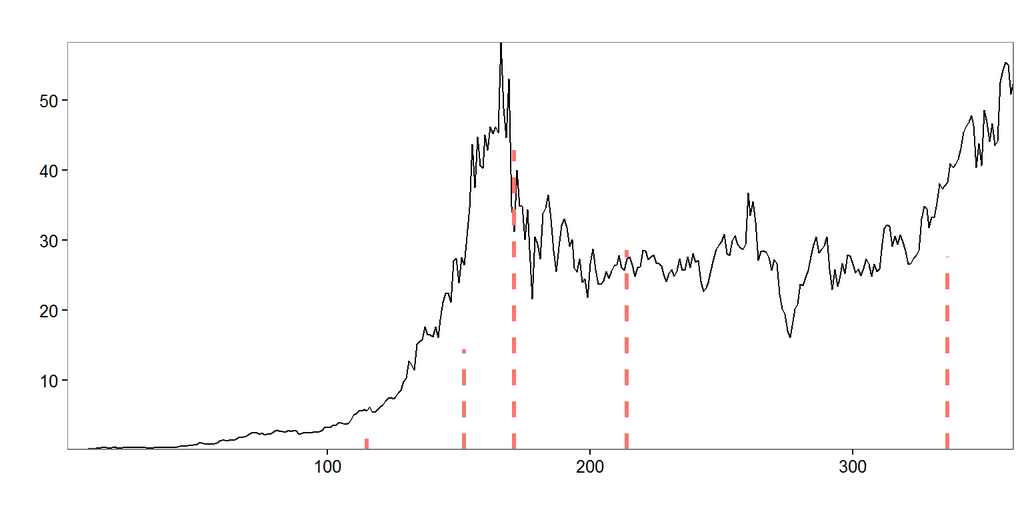

```r
changes <- breakout(msft_vec, plot = T,
                    method = 'multi', # detect multiple change points
                    min.size = 12)    # min(# obs.) between change points
changes$plot
```

## Acknowledgements

Thank you very much for your attention!

*Resources*

Quandl: https://www.quandl.com

ESD: https://en.wikipedia.org/wiki/Grubbs%27_test_for_outliers

AnomalyDetection: https://github.com/twitter/AnomalyDetection

BreakoutDetection: https://github.com/twitter/BreakoutDetection